QRMIAS: Tenth meeting

# Quantitative Research Methods: Introduction to Applied Statistics

David Sichinava, Rati Shubladze  
December 20, 2019

Tenth meeting

### Today's plans

- Assumptions of linear regression

### Today's datasets

```r
library(ggplot2)
### Get the dataset from here: https://goo.gl/vE26bN
poll08 <- read.csv("../data/pres08data.csv")
```

### Today's datasets

```r
summary(poll08)
```

```
      state.name     state        Obama           McCain            EV
 Alabama   : 1   AK     : 1   Min.   :33.00   Min.   : 7.00   Min.   : 3.00
 Alaska    : 1   AL     : 1   1st Qu.:43.00   1st Qu.:40.00   1st Qu.: 4.50
 Arizona   : 1   AR     : 1   Median :51.00   Median :47.00   Median : 8.00
 Arkansas  : 1   AZ     : 1   Mean   :51.37   Mean   :47.06   Mean   :10.55
 California: 1   CA     : 1   3rd Qu.:57.50   3rd Qu.:56.00   3rd Qu.:11.50
 Colorado  : 1   CO     : 1   Max.   :92.00   Max.   :66.00   Max.   :55.00
 (Other)   :45   (Other):45
     margin        predicted.margin.poll
 Min.   :-32.000   Min.   :-29.000
 1st Qu.:-13.000   1st Qu.: -9.500
 Median :  4.000   Median :  3.000
 Mean   :  4.314   Mean   :  3.252
 3rd Qu.: 17.500   3rd Qu.: 16.000
 Max.   : 85.000   Max.   : 69.000
```

```r
## Create a new variable which will indicate which candidate carried the state:

poll08$winner <- "Obama"
poll08$winner[poll08$Obama < poll08$McCain] <- "McCain"
table(poll08$winner)
```

```
McCain  Obama
    22     29
```

### Regression Assumptions:

- Linearity
- Homoscedasticity
- Independence
- Normal distribution

### What do we check for:

- Outliers
  - That is, extreme points;
- Leverage points
  - Points which have value too far away from the mean
- Influential observations
  - Points which significantly change the slope of the line

### What do we check for:

- We need to analyze *residuals*, that is the difference between *observed* and *actual* data;
- Fortunately, regression objects in \( R \) save all the information

### What do we check for:

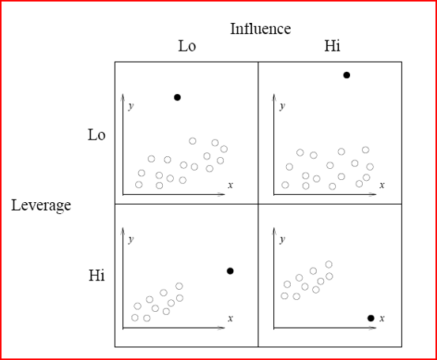

### What is our model:

- Vote Margin for Obama in Elections = \( \alpha \) + \( \beta \)*Vote margin for Obama in Polls + \( \epsilon \)

```r
model <- lm(margin~predicted.margin.poll, data=poll08)
summary(model)
```

```
Call:
lm(formula = margin ~ predicted.margin.poll, data = poll08)

Residuals:
     Min       1Q   Median       3Q      Max
-16.3834  -2.7205   0.3556   3.4224  13.0111

Coefficients:
                      Estimate Std. Error t value Pr(>|t|)
(Intercept)            0.70908    0.78695   0.901    0.372
predicted.margin.poll  1.10856    0.04063  27.285   <2e-16 ***
---
Signif. codes:  0 '***' 0.001 '**' 0.01 '*' 0.05 '.' 0.1 ' ' 1

Residual standard error: 5.54 on 49 degrees of freedom
Multiple R-squared:  0.9382,    Adjusted R-squared:  0.937
F-statistic: 744.5 on 1 and 49 DF,  p-value: < 2.2e-16
```

```r
model$r.squared
```

[output not shown]

### R-squared. R-What??

- R-squared measures how much of the variation in the dataset is explained by our model
- R-squared changes between 0 and 1:
  - 0 means that the model explains none of the variation in the dataset
  - 1 means that the model completely explains variation in the dataset

### Linearity:

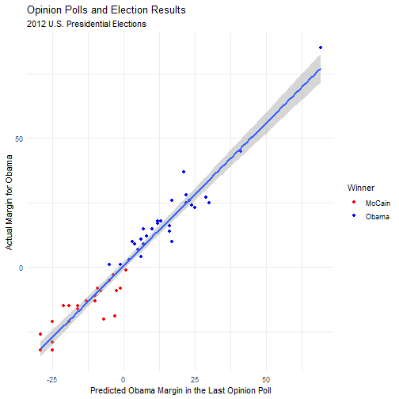

```r
ggplot(poll08, aes(x=predicted.margin.poll, y=margin))+
  geom_point(aes(color=winner))+
  geom_smooth(method='lm')+
  labs(title="Opinion Polls and Election Results",
       subtitle="2012 U.S. Presidential Elections",
       x="Predicted Obama Margin in the Last Opinion Poll",
       y="Actual Margin for Obama")+
          scale_color_manual(name="Winner",
                     values=c("red", "blue"))+
  theme_minimal()
```

### Linearity:

- Linearity assumption implies that the residuals are not too far away from zero

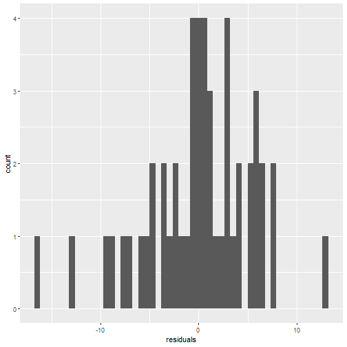

```r
poll08$residuals <- model$residuals
poll08$predicted <- predict(model)

ggplot(poll08, aes(x=residuals))+
  geom_histogram(bins = 51)
```

### Linearity:

- This also could be easily deduced if you check the mean of the residuals. It should be zero or **near zero**

```r
mean(poll08$residuals)
```

```
[1] -1.783534e-16
```

### Homoscedasticity:

- Homoscedasticity arises when the error term (that is, the differences between actual and predicted values) is constant, that is, the model produces equal variance
- You can easily check that on the plot
  - Ideally, if you plot fitted values against residuals, the points should not produce any pattern on the diagram

### Homoscedasticity:

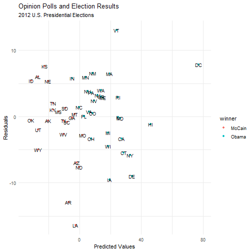

```r
ggplot(poll08, aes(x=predicted, y=residuals))+
  geom_point(aes(color=winner))+
  labs(title="Opinion Polls and Election Results",
       subtitle="2012 U.S. Presidential Elections",
       x="Predicted Values",
       y="Residuals")+
  geom_text(aes(label=state),
            position = position_dodge(width = 5),
            size=3)+
  theme_minimal()
```

### Homoscedasticity:

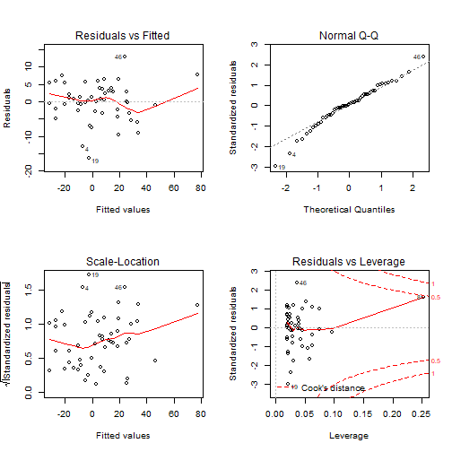

```r
par(mfrow=c(2,2))

plot(model)
```

### Homoscedasticity:

- Additional checks for *heteroscedasticity* are also visual:
  - Check residuals vs. fitted values diagram and scale-location charts
  - Again there should be *no pattern*

### Independence:

- It implies that the observations are not dependent on time and space
- Although variables which theoretically could be influenced by the two at the very first stage of model specification, you may check for them by plotting residuals against any time or order variables present in your datasets

### Independence:

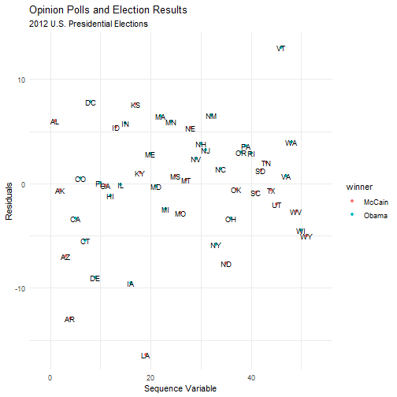

```r
ggplot(poll08, aes(x=seq(residuals), y=residuals))+
  geom_point(aes(color=winner))+
  labs(title="Opinion Polls and Election Results",
       subtitle="2012 U.S. Presidential Elections",
       x="Sequence Variable",
       y="Residuals")+
  geom_text(aes(label=state),
            position = position_dodge(width = 5),
            size=3)+
  theme_minimal()
```

### Normal distribution:

- Linear regression implies that your residuals are *normally distributed*.
- You can use \( plot() \) function and so called \( qqplots \) to evaluate your residuals

### Normal distribution:

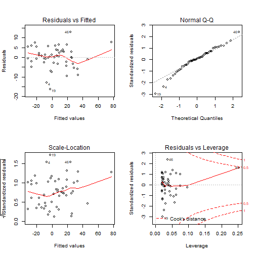

```r
par(mfrow=c(2,2))

plot(model)
```